# Survey 10 Results

Last update: 2021-11-10

# IMMUNIZATION PASSPORTS

## Immunization or vaccination passports have been suggested as a way to safely resume international travel.

## How do you feel about the idea of using an immunization or vaccination passports?

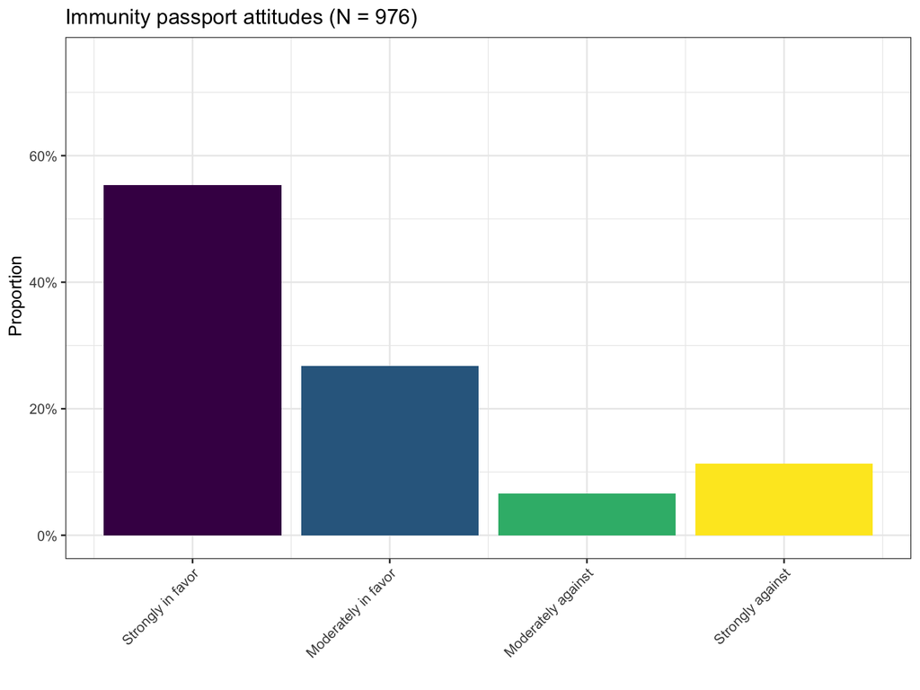

### Table corresponding to the graph above

1 = Strongly in favor

| immurec | n | prop |
| --- | --- | --- |
| 1 | 540 | 55.33 |
| 2 | 261 | 26.74 |
| 3 | 64 | 6.56 |
| 4 | 111 | 11.37 |

## ATTITUDES BY DEMOGRAPHICS

Just like for Survey 9, we would like to have the above plotted by various demographics, the numbers are shown below in separate tables.

**We would like to include proportion numbers (%) in the plots as well.**

### SEX

| sex | immurec | n | prop |
| --- | --- | --- | --- |
| male | strongly in favor | 135 | 0.56 |
| male | moderately in favor | 60 | 0.25 |
| male | moderately against | 14 | 0.06 |
| male | strongly against | 31 | 0.13 |
| female | strongly in favor | 402 | 0.55 |
| female | moderately in favor | 198 | 0.27 |
| female | moderately against | 50 | 0.07 |
| female | strongly against | 75 | 0.10 |

### AGE GROUP

| age_group | immurec | n | prop |
| --- | --- | --- | --- |
| 26 - 50y | strongly in favor | 248 | 0.51 |
| 26 - 50y | moderately in favor | 131 | 0.27 |
| 26 - 50y | moderately against | 39 | 0.08 |
| 26 - 50y | strongly against | 65 | 0.13 |
| over 51 | strongly in favor | 240 | 0.62 |
| over 51 | moderately in favor | 98 | 0.26 |
| over 51 | moderately against | 16 | 0.04 |
| over 51 | strongly against | 30 | 0.08 |
| under 25 | strongly in favor | 49 | 0.47 |
| under 25 | moderately in favor | 32 | 0.31 |
| under 25 | moderately against | 8 | 0.08 |
| under 25 | strongly against | 15 | 0.14 |

### EDUCATION

| edu | immurec | n | prop |
| --- | --- | --- | --- |
| primary | strongly in favor | 3 | 0.60 |
| primary | moderately in favor | 1 | 0.20 |
| primary | strongly against | 1 | 0.20 |
| secondary | strongly in favor | 84 | 0.57 |
| secondary | moderately in favor | 36 | 0.24 |
| secondary | moderately against | 9 | 0.06 |
| secondary | strongly against | 18 | 0.12 |
| college | strongly in favor | 187 | 0.58 |
| college | moderately in favor | 76 | 0.23 |
| college | moderately against | 17 | 0.05 |
| college | strongly against | 44 | 0.14 |
| graduate | strongly in favor | 263 | 0.53 |
| graduate | moderately in favor | 147 | 0.30 |
| graduate | moderately against | 38 | 0.08 |
| graduate | strongly against | 47 | 0.09 |

### INCOME

| hoinc | immurec | n | prop |
| --- | --- | --- | --- |
| bottom 3rd | strongly in favor | 60 | 0.47 |
| bottom 3rd | moderately in favor | 35 | 0.28 |
| bottom 3rd | moderately against | 13 | 0.10 |
| bottom 3rd | strongly against | 19 | 0.15 |
| middle 3rd | strongly in favor | 248 | 0.56 |
| middle 3rd | moderately in favor | 119 | 0.27 |
| middle 3rd | moderately against | 28 | 0.06 |
| middle 3rd | strongly against | 48 | 0.11 |
| top 3rd | strongly in favor | 149 | 0.58 |
| top 3rd | moderately in favor | 69 | 0.27 |
| top 3rd | moderately against | 18 | 0.07 |
| top 3rd | strongly against | 23 | 0.09 |

## To what extent would the introduction of ‘immunity passports’ influence your decision to get vaccinated?

Same as above, the plot below shows the overall sample, the subsequent tables are breaking it down by the demographic variables. Again, this is all the same as survey 9, just reproduced with data from Survey 10.

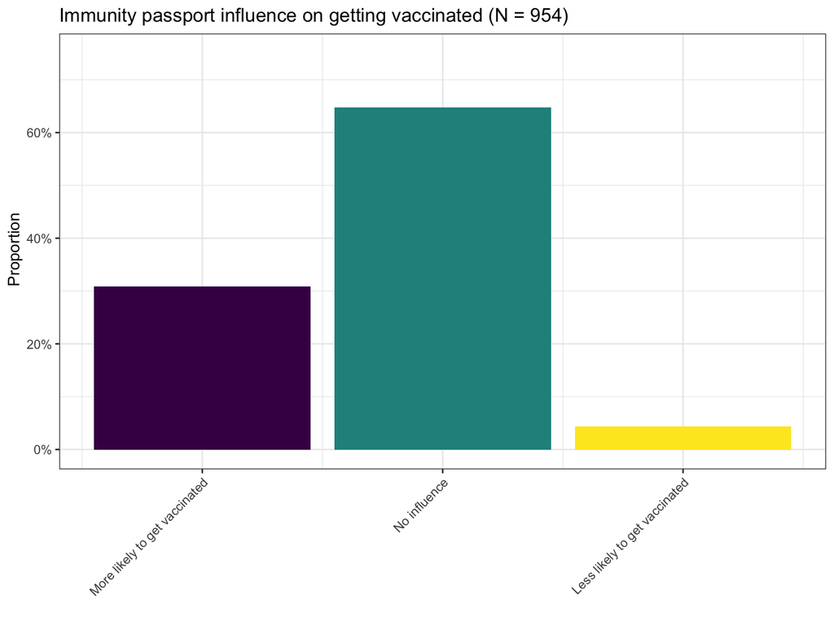

### Table corresponding to the plot

1 = It would make me more likely to get vaccinated

[output not shown]

### Vaccine status

| vaccine | immuinfl | n | prop |
| --- | --- | --- | --- |
| No | more likely to get vaccinated | 123 | 0.33 |
| No | no influence | 216 | 0.58 |
| No | less likely | 33 | 0.09 |
| Yes (partially) | more likely to get vaccinated | 78 | 0.24 |
| Yes (partially) | no influence | 238 | 0.74 |
| Yes (partially) | less likely | 5 | 0.02 |
| Yes (fully) | more likely to get vaccinated | 90 | 0.36 |
| Yes (fully) | no influence | 157 | 0.63 |
| Yes (fully) | less likely | 2 | 0.01 |
| Pref. not to answer | no influence | 1 | 1.00 |

### SEX

| sex | immuinfl | n | prop |
| --- | --- | --- | --- |
| male | more likely to get vaccinated | 62 | 0.26 |
| male | no influence | 159 | 0.68 |
| male | less likely | 14 | 0.06 |
| female | more likely to get vaccinated | 229 | 0.32 |
| female | no influence | 453 | 0.64 |
| female | less likely | 26 | 0.04 |

### AGE GROUP

| age_group | immuinfl | n | prop |
| --- | --- | --- | --- |
| 26 - 50y | more likely to get vaccinated | 157 | 0.33 |
| 26 - 50y | no influence | 296 | 0.62 |
| 26 - 50y | less likely | 24 | 0.05 |
| over 51 | more likely to get vaccinated | 87 | 0.24 |
| over 51 | no influence | 273 | 0.74 |
| over 51 | less likely | 10 | 0.03 |
| under 25 | more likely to get vaccinated | 49 | 0.48 |
| under 25 | no influence | 47 | 0.46 |
| under 25 | less likely | 6 | 0.06 |

### EDUCATION

| edu | immuinfl | n | prop |
| --- | --- | --- | --- |
| primary | more likely to get vaccinated | 1 | 0.17 |
| primary | no influence | 5 | 0.83 |
| secondary | more likely to get vaccinated | 49 | 0.33 |
| secondary | no influence | 91 | 0.62 |
| secondary | less likely | 7 | 0.05 |
| college | more likely to get vaccinated | 98 | 0.32 |
| college | no influence | 193 | 0.63 |
| college | less likely | 17 | 0.06 |
| graduate | more likely to get vaccinated | 146 | 0.30 |
| graduate | no influence | 326 | 0.67 |
| graduate | less likely | 17 | 0.03 |

### INCOME

| hoinc | immuinfl | n | prop |
| --- | --- | --- | --- |
| bottom 3rd | more likely to get vaccinated | 29 | 0.24 |
| bottom 3rd | no influence | 83 | 0.67 |
| bottom 3rd | less likely | 11 | 0.09 |
| middle 3rd | more likely to get vaccinated | 151 | 0.34 |
| middle 3rd | no influence | 272 | 0.62 |
| middle 3rd | less likely | 19 | 0.04 |
| top 3rd | more likely to get vaccinated | 68 | 0.27 |
| top 3rd | no influence | 177 | 0.71 |
| top 3rd | less likely | 5 | 0.02 |

## Demographcics overall - Who responded to survey 10

This is mostly informative - given that the separate plots already break down the responses by demographics, this could just be place informatively at the bottom/smaller print.

Again, some numbers might not exactly add up due to missing information.

### Sex

1 = male, 2 = female

```
## # A tibble: 2 × 5
## # Groups:   variable [1]
##   variable value     n sum_group  prop
##   <chr>    <dbl> <int>     <int> <dbl>
## 1 sex          1   208       863  24.1
## 2 sex          2   646       863  74.9
```

### Age

```
## # A tibble: 3 × 5
## # Groups:   variable [1]
##   variable  value     n sum_group  prop
##   <chr>     <dbl> <int>     <int> <dbl>
## 1 age_group     1    92       863  10.7
## 2 age_group     2   498       863  57.7
## 3 age_group     3   273       863  31.6
```

### Income

1 = lower 3rd, 2 = middle 3rd, 3 = upper 3rd

```
## # A tibble: 3 × 5
## # Groups:   variable [1]
##   variable value     n sum_group  prop
##   <chr>    <dbl> <int>     <int> <dbl>
## 1 hoinc        1   118       863  13.7
## 2 hoinc        2   427       863  49.5
## 3 hoinc        3   248       863  28.7
```

# **NEW**: ATTITUDES in CANADA (N = 395)

### How do you feel about the idea of using an immunization or vaccination passports?

| immurec | n | prop |
| --- | --- | --- |
| strongly in favor | 207 | 65.30 |
| moderately in favor | 61 | 19.24 |
| moderately against | 17 | 5.36 |
| strongly against | 32 | 10.09 |

### To what extent would the introduction of ‘immunity passports’ influence your decision to get vaccinated?

| immuinfl | n | prop |
| --- | --- | --- |
| more likely to get vaccinated | 79 | 25.00 |
| no influence | 218 | 68.99 |
| less likely | 19 | 6.01 |

# ADDITIONAL for Survey 10

Most of the data for survey 10 were collected in May and June. Availability of vaccine in Canada was widespread then.

### CANADA: Have you received a COVID-19 vaccine?

| vaccine | n | prop |
| --- | --- | --- |
| No | 90 | 0.23 |
| Yes (partially) | 229 | 0.58 |
| Yes (fully) | 29 | 0.07 |
| Pref. not to answer | 1 | 0.00 |
| NA | 46 | 0.12 |

### CANADA: If COVID-19 vaccine was available to you today, how likely are you to get it?

| vaccine_today | n | prop |
| --- | --- | --- |
| Extremely likely | 58 | 0.15 |
| Somewhat likely | 5 | 0.01 |
| Somewhat unlikely | 8 | 0.02 |
| Extremely unlikely | 16 | 0.04 |
| Pref. not to answer | 4 | 0.01 |
| NA | 304 | 0.77 |

### CANADA: What does/would greatly impact your choice for getting the COVID-19 vaccine?

We wanted to showcase the differences in motivations between those who are vaccinated versus not.

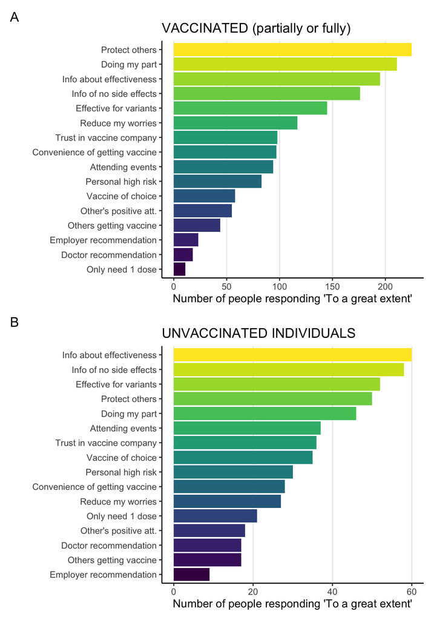

This document was prepared by UK - reach me with any questions/comments!